# minimum_viable_product_2014_09_19

```python
# Set up and read all relevant data into tables
import pandas as pd
import datetime
import numpy as np
# Used Texas A&M Geoservices to produce the following file.
station_census = pd.read_csv("Data/citibike_stations_census.csv",dtype=object)
station_census = station_census.ix[:331,:]
station_census = station_census.set_index('id')
```

```python
# Following are some helpful filtering and aggregation functions

# Restrict trip data to morning trips
def restrictHours(t, first_hour, last_hour):
    i = int(t[11:13]) # Extract the appropriate characters from the starttime field for the hour
    return i >= first_hour and i <= last_hour

# Apply an age bracket to the rider, given the birth year.  Assumes data from 2014
def age_bracket(age_str,brackets):
    try:
        a = int(age_str)
    except ValueError:
        return 'uxxxx'
    lower = '00'
    for i in range(len(brackets)):
        if a >= 2014 - brackets[i]:
            return 'u' + lower + str(brackets[i])
        lower = str(brackets[i]+1)
    if a >= 1901:
        return 'u' + lower + 'xx'
    return 'uxxxx'

############################################################

# Apply a sequence of filters to the data
def TripDataFilter(tripdata, filters):
    for f in filters:
        if f['type'] == 'RestrictHours':
            tripdata = tripdata[tripdata['starttime'].apply(lambda t: restrictHours(t,f['first'],f['last']))]
    return tripdata

def AddClassifiers(tripdata, classifiers):
    for c in classifiers:
        if c['t'] == "AgeBrackets": # Create age bracket classifiers where c['brackets'] contains the division points
            tripdata[c['colname']] = tripdata['birth year'].apply(lambda x: age_bracket(x,c['brackets']))
        if c['t'] == "Counter":
            tripdata[c['colname']] = 'COUNT'
    return tripdata

# Create a dataframe that has counts of values of ref by index
def GroupByCount(data,index,column_names = None,refs=[]):
    gb = data.groupby([index]+refs)
    agg = gb[index].count()
    for i in range(len(refs)):
        agg = agg.unstack()
    agg = agg.fillna(0)
    if (column_names):
        agg.rename(columns=column_names,inplace=True)
    return agg

def GroupVariables(data,index,agg_pipeline):
    gb = data.groupby(index)
    ret = pd.DataFrame(gb[index].count())
    del ret[index]
    for a in agg_pipeline:
        col_names = None
        if 'column_names' in a:
            col_names = a['column_names']
        suffixes = ['','']
        if 'suffixes' in a:
            suffixes = a['suffixes']
        ret = ret.join(GroupByCount(data,index,refs=a['refs'],column_names = col_names),rsuffix = suffixes[1])
    return ret

# Read in the trip data and combine it into a dataframe with statistics
def read_data(y,m,filters=[],classifiers=[],groups=[],dfindex=''):
    y = str(y)
    m = str(m)
    if (len(m)==1):
        m = '0'+m
    cb2 = pd.read_csv("Data/"+y+"-"+m+" - Citi Bike trip data.csv",dtype=object)
    cb2 = TripDataFilter(cb2, filters)
    cb2 = AddClassifiers(cb2, classifiers)
    grouped = GroupVariables(cb2,dfindex,groups)
    return grouped

def ReadMultiData(dates,filters=[],classifiers=[],groups=[],dfindex=''):
    StationCount = read_data(dates[0][0],dates[0][1], filters=filters, classifiers=classifiers, groups=groups,dfindex=dfindex)
    for i in range(1,len(dates)):
        new_data = read_data(dates[i][0],dates[i][1], filters=filters, classifiers=classifiers,groups=groups,dfindex=dfindex)
        for col in new_data.columns.values:
            if col not in StationCount.columns.values:
                StationCount[col] = 0
        for col in StationCount.columns.values:
            if col not in new_data.columns.values:
                new_data[col] = 0
        StationCount += new_data
    return StationCount
```

```python
all_months = [[2013,i] for i in range(7,13)] + [[2014,i] for i in range(1,6)]
StationCount = ReadMultiData(all_months,
                             filters = [{'type':'RestrictHours','first':5,'last':11}],
                             classifiers = [{'t':'AgeBrackets','colname':'age','brackets':[17,24,34,44,54,64]},
                                            {'t':'Counter','colname':'COUNT'}],
                             dfindex='start station id',
                             groups = [{'refs':['age']},{'refs':['COUNT']}])
StationCount = StationCount.join(station_census)
```

```python
# Extract and add the census block group and tract to each entry in the age table.  This will help with merging
def toBlockTract(geoid):
    geoid = str(geoid)
    try:
        tract = geoid[2:9]
    except ValueError:
        return "0"
    try:
        block = geoid[9:11] # Change to [9:12] to incorporate the block group
    except ValueError:
        return "0"
    return tract + '.' + block
StationCount['FullCensusTract'] = StationCount.apply(lambda row: row.CensusCountyFips + row.CensusTract,axis=1)
CensusBlock = StationCount.groupby('FullCensusTract').sum().fillna(0)
```

```python
from sklearn import linear_model
from sklearn import utils
StationCount['COUNT'] = StationCount['COUNT'].fillna(0)
count = CensusBlock['COUNT']
from scipy import stats

# Build a linear model based selected inputs from a csv file
# The CSV file should provide data for all census blocks in the CitiBike network and
# be formatted in the matter of US Census files.
def BuildLinearModel(filename,agg_cols,name='',col_names=[]):
    raw_data = pd.read_csv(filename,dtype=object).ix[2:,:]
    raw_data["asdf"] = raw_data["GEO.id2"].apply(toBlockTract)
    # This operation is necessary to index on tracts rather than block groups
    for i in range(len(agg_cols)):
        for j in range(len(agg_cols[i])):
            raw_data[agg_cols[i][j]] = raw_data[agg_cols[i][j]].astype(float)
    sum_agg = []
    for i in range(len(agg_cols)):
        for j in range(len(agg_cols[i])):
            sum_agg.append(agg_cols[i][j])
    raw_data_tract = raw_data.ix[:,sum_agg+['asdf']].groupby('asdf').sum()
    StationCount_aug = CensusBlock.join(raw_data_tract)
    # Trim obviously bad values
    StationCount_aug = StationCount_aug[CensusBlock['COUNT']>0]
    global count
    count = count[CensusBlock['COUNT'] > 0]
    # Convert data frame columns from strings to floats
    float_conv = []
    for i in range(len(agg_cols)):
        for j in range(len(agg_cols[i])):
            float_conv.append(agg_cols[i][j])
    for col in float_conv:
        StationCount_aug[col] = StationCount_aug[col].astype(float)
    # Build the X dataframe for the linear regression
    new_df_dict = {}
    single_var_regressions = []
    for i in range(len(agg_cols)):
        new_col = StationCount_aug[agg_cols[i][0]]
        for j in range(1,len(agg_cols[i])):
            new_col = new_col + StationCount_aug[agg_cols[i][j]]
        new_df_dict['x'+str(i)] = new_col
        single_var_regressions.append(pd.DataFrame({'variable':new_col}))
    StationData = pd.DataFrame(new_df_dict)
    # Conduct the linear regression
    clf = linear_model.LinearRegression().fit(StationData,count)
    ret_value = [clf,[]]
    for i in range(len(single_var_regressions)):
        clf_single = linear_model.LinearRegression().fit(single_var_regressions[i],count)
        ret_value[1].append([clf_single,single_var_regressions[i]])
    return ret_value

# Inverse of conditioning number
#xtx_eig = sort(np.linalg.eig(np.dot(StationDataFamStruct.values.T, StationDataFamStruct.values))[0])
#xtx_eig[0] / xtx_eig[len(xtx_eig)-1]
```

```
Intercept of this regression is 9150.24739117 and the slope is [ 0.89889501]
The correlation and significance between usage and population is (0.21528250404767035, 0.0060958793926952524)
```

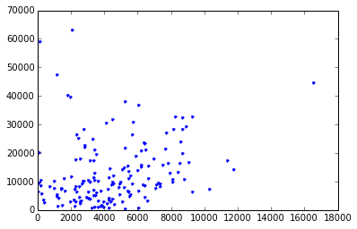

```python
# To establish a baseline and to get a measure of variability, we measure CitiBike usage against population.
# The x-axis is the population of a census tract
# The y-axis is the number of morning trips (5 AM to 11:59 AM) that originate in that census block.
# The reason for measuring morning trips is that these are more likely to be made by people who actually live in the area.

UsageByPop = BuildLinearModel("Data/AgeBySex/AgeBySex.csv",[['D001']],"Population",["pop"])
print "Intercept of this regression is " + str(UsageByPop[0].intercept_) + " and the slope is " + str(UsageByPop[0].coef_)
print "The correlation and significance between usage and population is " + \
  str(stats.pearsonr(count.values,[x[0] for x in UsageByPop[1][0][1].values.tolist()]))
matplotlib.pyplot.plot(UsageByPop[1][0][1],count,'.')
```

We see that each person who lives in the vicinity of a CitiBike station will make, on average, about one morning trip per year. However, the high variability indicates the presence of confounding factors. Some population profiles should be expected to use the CitiBike system much more than others. Also, since census tracts are rather small, many people will not use stations in their own census tracts if another nearby station is more convenient.

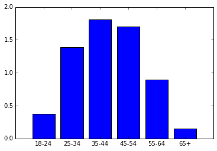

```python
# For age, we compare the proportion of usage by age bracket against the proportion of actual residents by age bracket

raw_data = pd.read_csv("Data/AgeBySex/AgeBySex.csv",dtype=object).ix[2:,:]
raw_data["FullCensusTract"] = raw_data["GEO.id2"].apply(toBlockTract)

# Leaving out 3,4,5,6,27,28,29,30
AgeColumns = [['D007','D008','D009','D010',
                                                'D031','D032','D033','D034'],
                                               ['D011','D012','D035','D036'],
                                               ['D013','D014','D037','D038'],
                                               ['D015','D016','D039','D040'],
                                               ['D017','D018','D019','D041','D042','D043'],
                                               ['D020','D021','D022','D044','D045','D046',
                                                'D023','D024','D025','D047','D048','D049']]
AllAgeColumns = ['D001']
for i in range(len(AgeColumns)):
    for j in range(len(AgeColumns[i])):
        AllAgeColumns.append(AgeColumns[i][j])
for col in AllAgeColumns:
    raw_data[col] = raw_data[col].astype(float)
raw_data_tract = raw_data.ix[:,AllAgeColumns+['FullCensusTract']].groupby('FullCensusTract').sum()
#StationCount_aug = CensusBlock.join(raw_data_tract)
StationCount
CensusTractCount = StationCount.ix[:,['FullCensusTract','u1824','u2534','u3544','u4554','u5564','u65xx']].groupby('FullCensusTract').sum().fillna(0)
CensusTractCount = CensusTractCount.join(raw_data_tract)
for i in range(len(AgeColumns)):
    CensusTractCount['a'+str(i)] = CensusTractCount[AgeColumns[i][0]]
    for j in range(1,len(AgeColumns[i])):
        CensusTractCount['a'+str(i)] = CensusTractCount['a'+str(i)] + CensusTractCount[AgeColumns[i][j]]
CensusTractCount['u_total'] = CensusTractCount['u1824'] + CensusTractCount['u2534'] + CensusTractCount['u3544'] +\
         CensusTractCount['u4554'] + CensusTractCount['u5564'] + CensusTractCount['u65xx']
CensusTractCount = CensusTractCount[CensusTractCount['u_total'] > 0]
C = CensusTractCount
CensusTractCount['coef0024'] = CensusTractCount['u1824'] * CensusTractCount['D001'] / CensusTractCount['u_total'] / CensusTractCount['a0']
CensusTractCount['coef2534'] = CensusTractCount['u2534'] * CensusTractCount['D001'] / CensusTractCount['u_total'] / CensusTractCount['a1']
CensusTractCount['coef3544'] = CensusTractCount['u3544'] * CensusTractCount['D001'] / CensusTractCount['u_total'] / CensusTractCount['a2']
CensusTractCount['coef4554'] = CensusTractCount['u4554'] * CensusTractCount['D001'] / CensusTractCount['u_total'] / CensusTractCount['a3']
CensusTractCount['coef5564'] = CensusTractCount['u5564'] * CensusTractCount['D001'] / CensusTractCount['u_total'] / CensusTractCount['a4']
CensusTractCount['coef65xx'] = CensusTractCount['u65xx'] * CensusTractCount['D001'] / CensusTractCount['u_total'] / CensusTractCount['a5']
age_props = []
age_props.append(C['u1824'].sum() * C['D001'].sum() / C['u_total'].sum() / C['a0'].sum())
age_props.append(C['u2534'].sum() * C['D001'].sum() / C['u_total'].sum() / C['a1'].sum())
age_props.append(C['u3544'].sum() * C['D001'].sum() / C['u_total'].sum() / C['a2'].sum())
age_props.append(C['u4554'].sum() * C['D001'].sum() / C['u_total'].sum() / C['a3'].sum())
age_props.append(C['u5564'].sum() * C['D001'].sum() / C['u_total'].sum() / C['a4'].sum())
age_props.append(C['u65xx'].sum() * C['D001'].sum() / C['u_total'].sum() / C['a5'].sum())
plt.bar(range(len(age_props)), age_props, align='center')
plt.xticks(range(len(age_props)), ['18-24','25-34','35-44','45-54','55-64','65+'])
plt.show()
```

The above shows that the heaviest CitiBike users are in the 35-44 age range, folowed by the 45-54 range. This suggests that a successful bike sharing program should target neighborhoods with larger numbers of people in these age ranges.

```
Intercept of this regression is 8783.60090373 and the coefficients are [-0.99218186  2.8249813 ]
The correlation and significance between usage and the number of home owners is (0.054882358968775961, 0.48926747038700169)
```

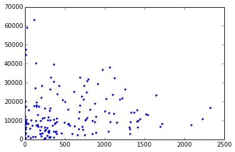

```python
# Now we examine how CitiBike stations performs in terms of numbers of owned homes and rentals.
# Here an owned home is defined to be a housing unit occupied by its owner, whether with a mortgage/loan or owned free and clear.
# A rental is a housing unit that is occupied by renters.
# These numbers are derived from the 2010 US Census.
OwnRent = BuildLinearModel("Data/households_age/HouseholdsAges.csv",[['HD01_S02','HD01_S03'],['HD01_S04']])
print "Intercept of this regression is " + str(OwnRent[0].intercept_) + " and the coefficients are " + str(OwnRent[0].coef_)
print "The correlation and significance between usage and the number of home owners is " + \
  str(stats.pearsonr(count.values,[x[0] for x in OwnRent[1][0][1].values.tolist()]))
matplotlib.pyplot.plot(OwnRent[1][0][1],count,'.')
```

```
If we look just at the relationship between renters and CitiBike usage, we get an intercept and slope of [8454.365065378297, array([ 2.70272437])]
The correlation and significance between usage and the number of renters is (0.30545739702658825, 8.1409120639446586e-05)
The average number of renters per rental property is 1.83144790895
```

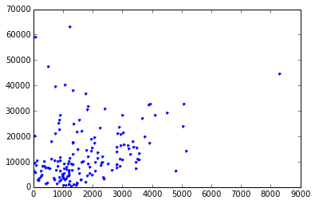

```python
print "If we look just at the relationship between renters and CitiBike usage, we get an intercept and slope of " +\
  str([OwnRent[1][1][0].intercept_, OwnRent[1][1][0].coef_])
print "The correlation and significance between usage and the number of renters is " + \
  str(stats.pearsonr(count.values,[x[0] for x in OwnRent[1][1][1].values.tolist()]))
matplotlib.pyplot.plot(OwnRent[1][1][1],count,'.')
# Now we load renter data to determine the average size of a rented household and the CitiBike contribution of a renter
raw_data = pd.read_csv("Data/households_age/HouseholdsAges.csv",dtype=object).ix[2:,:]
raw_data["FullCensusTract"] = raw_data["GEO.id2"].apply(toBlockTract)

AgeColumns = ['HD01_S'+str(i) for i in range(13,21)]
for col in AgeColumns:
    raw_data[col] = raw_data[col].astype(float)
raw_data_tract = raw_data.ix[:,AgeColumns+['FullCensusTract']].groupby('FullCensusTract').sum()
CensusTractCount = StationCount.ix[:,['FullCensusTract']].groupby('FullCensusTract').sum().fillna(0)
C = CensusTractCount.join(raw_data_tract)
print "The average number of renters per rental property is " + str((C['HD01_S14'].sum() + 2*C['HD01_S15'].sum() + \
                                                               3*C['HD01_S16'].sum() + 4*C['HD01_S17'].sum() + \
  5*C['HD01_S18'].sum() + 6*C['HD01_S19'].sum() + 7*C['HD01_S20'].sum()) / C['HD01_S13'].sum())
```

```python
# Race.  The order is White, Black, Asian, and Other races
# (includes Pacific Islander, American, and Other, as reported from the 2010 US Census)
Race = BuildLinearModel("Data/aff_download/DEC_10_SF1_P6_with_ann.csv",[['D002'],['D003'],['D005'],['D004','D006','D007']],
                 "Race",["White","Black","Asian","Other"])
print "Intercept of this regression is " + str(Race[0].intercept_) + " and the coefficients are " + str(Race[0].coef_)
```

```
Intercept of this regression is 10877.3529437 and the coefficients are [ 1.3803761  -3.33928588  0.89870747 -2.91438319]
```

```
The intercept and slope for whites are [8464.1327364438112, array([ 1.58261072])]
The correlation and significance between usage and the number of white residents is (0.30566753331396657, 8.0447995300881586e-05)
```

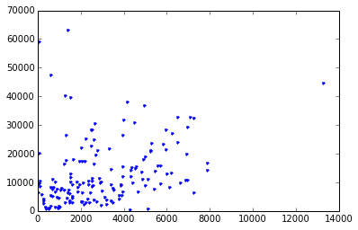

```python
# Now we look at each of the four racial groups individually.  For whites, we get the following.
print "The intercept and slope for whites are " +\
  str([Race[1][0][0].intercept_, Race[1][0][0].coef_])
print "The correlation and significance between usage and the number of white residents is " + \
  str(stats.pearsonr(count.values,[x[0] for x in Race[1][0][1].values.tolist()]))
matplotlib.pyplot.plot(Race[1][0][1],count,'.')
```

```
The intercept and slope for blacks are [15672.629236687166, array([-4.85921712])]
The correlation and significance between usage and the number of black residents is (-0.2832137249561768, 0.00027221250416734327)
```

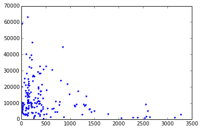

```python
print "The intercept and slope for blacks are " +\
  str([Race[1][1][0].intercept_, Race[1][1][0].coef_])
print "The correlation and significance between usage and the number of black residents is " + \
  str(stats.pearsonr(count.values,[x[0] for x in Race[1][1][1].values.tolist()]))
matplotlib.pyplot.plot(Race[1][1][1],count,'.')
```

```
The intercept and slope for Asians are [12175.467486907322, array([ 1.19300386])]
The correlation and significance between usage and the number of Asian residents is (0.13236592080725199, 0.094165616782953945)
```

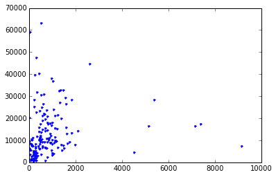

```python
print "The intercept and slope for Asians are " +\
  str([Race[1][2][0].intercept_, Race[1][2][0].coef_])
print "The correlation and significance between usage and the number of Asian residents is " + \
  str(stats.pearsonr(count.values,[x[0] for x in Race[1][2][1].values.tolist()]))
matplotlib.pyplot.plot(Race[1][2][1],count,'.')
```

```
The intercept and slope for other races are [14453.249139154359, array([-4.02380649])]
The correlation and significance between usage and the number of white residents is (-0.1353027910238814, 0.08702549632356342)
```

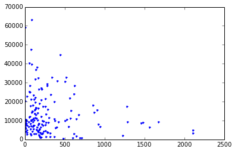

```python
print "The intercept and slope for other races are " +\
  str([Race[1][3][0].intercept_, Race[1][3][0].coef_])
print "The correlation and significance between usage and the number of white residents is " + \
  str(stats.pearsonr(count.values,[x[0] for x in Race[1][3][1].values.tolist()]))
matplotlib.pyplot.plot(Race[1][3][1],count,'.')
```

```python
# Analysis of mixed race census blocks and CitiBike usage.
# The first term is the number of racially homogeneous households, while the second term is racially mixed
MixedRace = BuildLinearModel("Data/aff_download/DEC_10_SF1_P8_with_ann.csv",[['D002'],['D009']])
print "Intercept of this regression is " + str(MixedRace[0].intercept_) + " and the coefficients are " + str(MixedRace[0].coef_)
```

```
Intercept of this regression is 9545.65451575 and the coefficients are [  1.43375819 -17.21079834]
```

```
The intercept and slope for homogeneous households are [9136.894790417422, array([ 0.93299168])]
The correlation with usage and significance are (0.21708464200304808, 0.0056731455968498726)
```

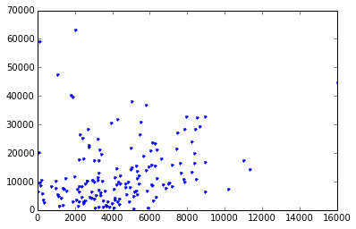

```python
print "The intercept and slope for homogeneous households are " +\
  str([MixedRace[1][0][0].intercept_, MixedRace[1][0][0].coef_])
print "The correlation with usage and significance are " + \
  str(stats.pearsonr(count.values,[x[0] for x in MixedRace[1][0][1].values.tolist()]))
matplotlib.pyplot.plot(MixedRace[1][0][1],count,'.')
```

```
The intercept and slope for heterogeneous households are [10960.622522190837, array([ 14.93062344])]
The correlation with usage and significance are (0.12515603917335313, 0.1136713150669653)
```

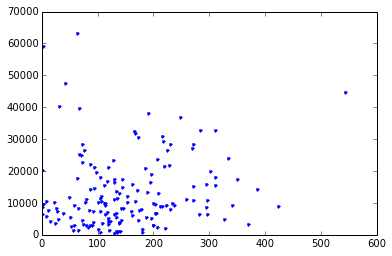

```python
print "The intercept and slope for heterogeneous households are " +\
  str([MixedRace[1][1][0].intercept_, MixedRace[1][1][0].coef_])
print "The correlation with usage and significance are " + \
  str(stats.pearsonr(count.values,[x[0] for x in MixedRace[1][1][1].values.tolist()]))
matplotlib.pyplot.plot(MixedRace[1][1][1],count,'.')
```

The above shows that racially homogeneous households correlate better with CitiBike usage than heterogeneous households. This may reflect the same phenomenon observed above when comparing race with CitiBike usage.

```python
# Households with nonrelatives: with nonrelatives, then without
NonRel = BuildLinearModel("Data/aff_download/DEC_10_SF1_P27_with_ann.csv",[['D002'],['D003']])
print "Intercept of this regression is " + str(NonRel[0].intercept_) + " and the coefficients are " + str(NonRel[0].coef_)
```

```
Intercept of this regression is 8957.04667727 and the coefficients are [ 11.68567529  -0.4155159 ]
```

```
The intercept and slope for households with nonrelatives are [8658.7092669261838, array([ 10.56686805])]
The correlation with usage and significance are (0.33319289559577947, 1.568340185795425e-05)
```

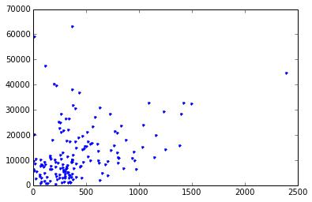

```python
print "The intercept and slope for households with nonrelatives are " +\
  str([NonRel[1][0][0].intercept_, NonRel[1][0][0].coef_])
print "The correlation with usage and significance are " + \
  str(stats.pearsonr(count.values,[x[0] for x in NonRel[1][0][1].values.tolist()]))
matplotlib.pyplot.plot(NonRel[1][0][1],count,'.')
```

```
The intercept and slope for households without nonrelatives are [8917.6059833247091, array([ 2.28669205])]
The correlation with usage and significance are (0.24604155751814405, 0.0016546359357511654)
```

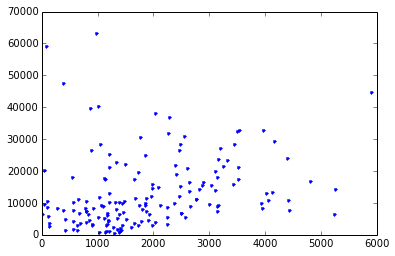

```python
print "The intercept and slope for households without nonrelatives are " +\
  str([NonRel[1][1][0].intercept_, NonRel[1][1][0].coef_])
print "The correlation with usage and significance are " + \
  str(stats.pearsonr(count.values,[x[0] for x in NonRel[1][1][1].values.tolist()]))
matplotlib.pyplot.plot(NonRel[1][1][1],count,'.')
```

The presence of households both with and without nonrelatives both correlate positive to CitiBike usage, reflecting their correlation with overall population. But households with nonrelatives correlate much more strongly: every such household contributes about 12 annual morning trips.

```python
# Household structure: family, nonfamily, group
# As defined by the 2010 US Census, a family household contains at least one person related to or married to
# the householder (excluding same sex partners).  Otherwise, it is a nonfamily househould.
# Group housing refers to facilities such as dormitories or prisons.
Struct = BuildLinearModel("Data/aff_download/DEC_10_SF1_P29_with_ann.csv",[['D003'],['D018'],['D026']],
                 "Household structure",["Family housing","Nonfamily housing","Group housing"])
print "Intercept of this regression is " + str(Struct[0].intercept_) + " and the coefficients are " + str(Struct[0].coef_)
```

```
Intercept of this regression is 9591.62495773 and the coefficients are [-0.76691478  2.67156962 -0.05503532]
```

```
The intercept and slope for family households are [12687.54435306825, array([ 0.23252686])]
The correlation with usage and significance are (0.033444174505119981, 0.67363071745933212)
```

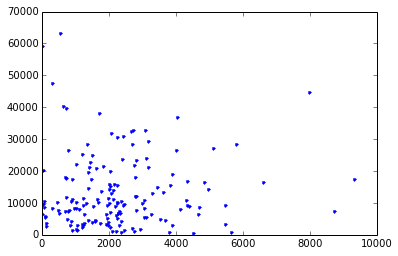

```python
print "The intercept and slope for family households are " +\
  str([Struct[1][0][0].intercept_, Struct[1][0][0].coef_])
print "The correlation with usage and significance are " + \
  str(stats.pearsonr(count.values,[x[0] for x in Struct[1][0][1].values.tolist()]))
matplotlib.pyplot.plot(Struct[1][0][1],count,'.')
```

```
The intercept and slope for family households are [8467.159931776041, array([ 2.36146402])]
The correlation with usage and significance are (0.32735752365535975, 2.2479301961248109e-05)
```

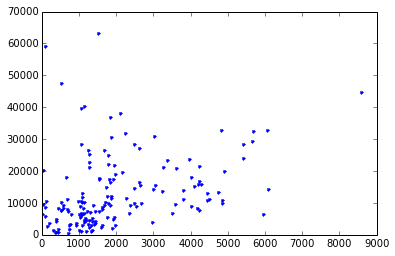

```python
print "The intercept and slope for family households are " +\
  str([Struct[1][1][0].intercept_, Struct[1][1][0].coef_])
print "The correlation with usage and significance are " + \
  str(stats.pearsonr(count.values,[x[0] for x in Struct[1][1][1].values.tolist()]))
matplotlib.pyplot.plot(Struct[1][1][1],count,'.')
```

```
The intercept and slope for family households are [12963.305140056467, array([ 1.00316225])]
The correlation with usage and significance are (0.037063155264735741, 0.64066099930441056)
```

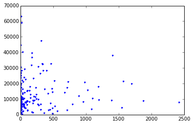

```python
print "The intercept and slope for family households are " +\
  str([Struct[1][2][0].intercept_, Struct[1][2][0].coef_])
print "The correlation with usage and significance are " + \
  str(stats.pearsonr(count.values,[x[0] for x in Struct[1][2][1].values.tolist()]))
matplotlib.pyplot.plot(Struct[1][2][1],count,'.')
```

Of the three classes of households, nonfamily households are the best predictor of CitiBike usage, with every such household contributing about 2.5 annual morning CitiBike trips. CitiBike usage has no significant correlation with family households or with group quarters.

A general observation is that in all of the above plots, linear models are weak fits of the data. This suggests that far more information than basic demographic statistics is needed to predict ridership at a bike sharing station.